# R-Bridge-Final

A.S

August 9, 2016

## R Final Project Description

This project is where you show off your ability to  
(1) use R packages  
(2) change the shape of data in a data frame  
(3) provide basic summary statistics and graphics as part of your exploratory data analysis.

. You should start by installing and loading the R package hflights, which is available on CRAN and described here: https://cran.r-project.org/web/packages/hflights/hflights.pdf

. You should perform some basic transformations on the data frame, such as including only a subset of columns, created one or more new derived columns (such as flight date), and/or filtering out rows.

. You should then create basic summary statistics. You should create at least one interesting question for analysis, and answer the question using two or more graphics in R.

```r
#install.packages("hflights")

library(ggplot2)
library(gcookbook)
library(hflights)
library(sqldf)
```

#### Get the number of rows in the dataset

```r
nrow(hflights)
```

```
## [1] 227496
```

#### Get the number of columns in the dataset

```r
ncol(hflights)
```

```
## [1] 21
```

#### Get column names in the dataset

```r
colnames(hflights)
```

```
##  [1] "Year"              "Month"             "DayofMonth"
##  [4] "DayOfWeek"         "DepTime"           "ArrTime"
##  [7] "UniqueCarrier"     "FlightNum"         "TailNum"
## [10] "ActualElapsedTime" "AirTime"           "ArrDelay"
## [13] "DepDelay"          "Origin"            "Dest"
## [16] "Distance"          "TaxiIn"            "TaxiOut"
## [19] "Cancelled"         "CancellationCode"  "Diverted"
```

#### Check the first 10 rows of the dataset

```r
head(hflights, n=10)
```

```
##      Year Month DayofMonth DayOfWeek DepTime ArrTime UniqueCarrier
## 5424 2011     1          1         6    1400    1500            AA
## 5425 2011     1          2         7    1401    1501            AA
## 5426 2011     1          3         1    1352    1502            AA
## 5427 2011     1          4         2    1403    1513            AA
## 5428 2011     1          5         3    1405    1507            AA
## 5429 2011     1          6         4    1359    1503            AA
## 5430 2011     1          7         5    1359    1509            AA
## 5431 2011     1          8         6    1355    1454            AA
## 5432 2011     1          9         7    1443    1554            AA
## 5433 2011     1         10         1    1443    1553            AA
##      FlightNum TailNum ActualElapsedTime AirTime ArrDelay DepDelay Origin
## 5424       428  N576AA                60      40      -10        0    IAH
## 5425       428  N557AA                60      45       -9        1    IAH
## 5426       428  N541AA                70      48       -8       -8    IAH
```

[output cut: 18 more lines]

#### Select only required columns

```r
hflights_df = hflights[c("UniqueCarrier","Month","DayofMonth", "Year",
                         "Origin","Dest","DepTime", "ArrTime", "DepDelay", "ArrDelay",
                         "Cancelled","CancellationCode")]
head(hflights_df, 10)
```

```
##      UniqueCarrier Month DayofMonth Year Origin Dest DepTime ArrTime
## 5424            AA     1          1 2011    IAH  DFW    1400    1500
## 5425            AA     1          2 2011    IAH  DFW    1401    1501
## 5426            AA     1          3 2011    IAH  DFW    1352    1502
## 5427            AA     1          4 2011    IAH  DFW    1403    1513
## 5428            AA     1          5 2011    IAH  DFW    1405    1507
## 5429            AA     1          6 2011    IAH  DFW    1359    1503
## 5430            AA     1          7 2011    IAH  DFW    1359    1509
## 5431            AA     1          8 2011    IAH  DFW    1355    1454
## 5432            AA     1          9 2011    IAH  DFW    1443    1554
## 5433            AA     1         10 2011    IAH  DFW    1443    1553
##      DepDelay ArrDelay Cancelled CancellationCode
## 5424        0      -10         0
## 5425        1       -9         0
## 5426       -8       -8         0
## 5427        3        3         0
## 5428        5       -3         0
## 5429       -1       -7         0
## 5430       -1       -1         0
## 5431       -5      -16         0
## 5432       43       44         0
## 5433       43       43         0
```

#### Extract column UniqueCarrier into a dataframe carrier_df

```r
carrier_df = hflights_df [c("UniqueCarrier")]
```

#### Check the number of rows in the data frame carrier_df. Make sure you have all the rows

```r
nrow(carrier_df)
```

```
## [1] 227496
```

#### Plot a Bar Graph for each Carrier type. Display Carrier on X-axis and Carrier Count on Y-axis

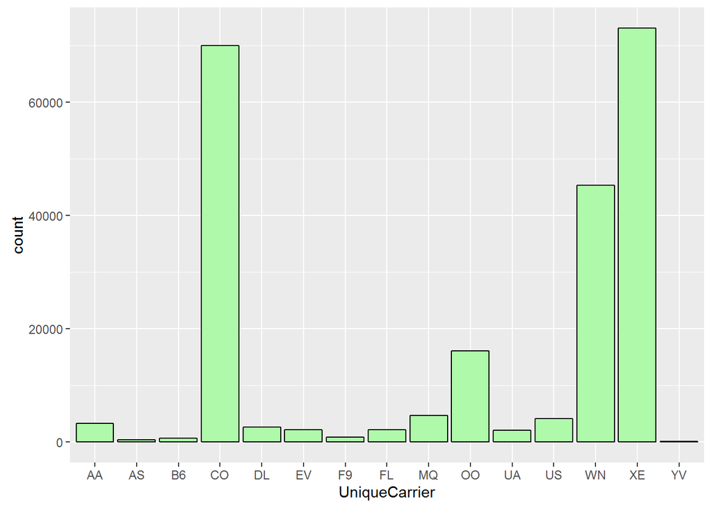

```r
ggplot(carrier_df, aes(x=UniqueCarrier), stat="count") + geom_bar(fill="#AFFAAA", color="black")
```

#### What are the different origins and their count of flights?

```r
origins_df=sqldf("select Origin, count(*) As NumberOfFlights from hflights_df group by Origin")
print(origins_df)
```

```
##   Origin NumberOfFlights
## 1    HOU           52299
## 2    IAH          175197
```

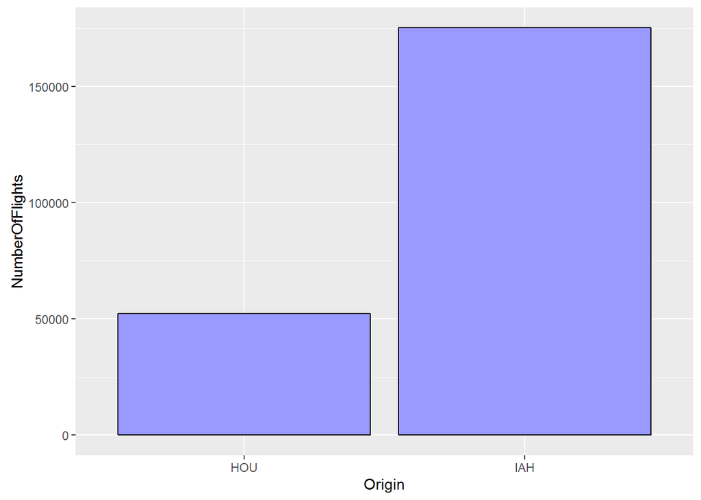

```r
ggplot(origins_df, aes(x=Origin, y=NumberOfFlights)) + geom_bar(fill="#9999ff", color="black", stat="identity")
```

#### What are the top 20 destinations and thier counts of flights?

```r
destinations_df = sqldf("select Dest, NumberOfFlights from (select Dest, count(*) As NumberOfFlights from hflights_df group by Dest) order by NumberOfFlights desc")
nrow(destinations_df)
```

```
## [1] 116
```

```r
destinations_df = head(destinations_df, 20)
print (destinations_df)
```

```
##    Dest NumberOfFlights
## 1   DAL            9820
## 2   ATL            7886
## 3   MSY            6823
## 4   DFW            6653
## 5   LAX            6064
## 6   DEN            5920
## 7   ORD            5748
## 8   PHX            5096
## 9   AUS            5022
## 10  SAT            4893
## 11  CRP            4813
## 12  CLT            4735
## 13  EWR            4314
## 14  LAS            4082
## 15  HRL            3983
## 16  MCO            3687
## 17  BNA            3481
## 18  MCI            3174
## 19  OKC            3170
## 20  TPA            3085
```

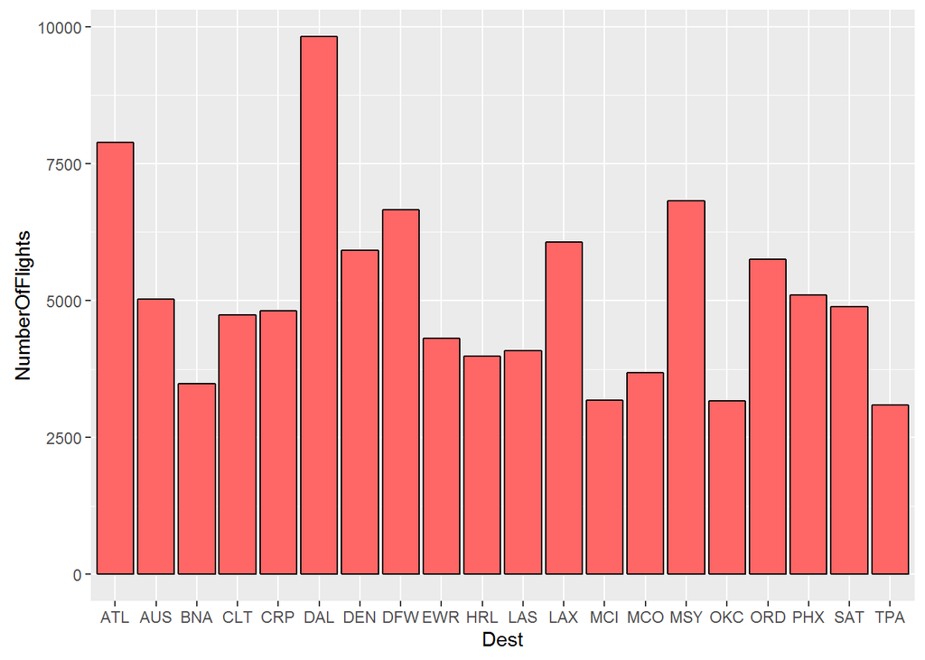

```r
ggplot(destinations_df, aes(x=Dest, y=NumberOfFlights)) + geom_bar(fill="#ff6666", color="black", stat="identity")
```

#### Add a new column called flight date and find the number of flights in each month

```r
hflights_df$Date = paste( hflights_df$Month , hflights_df$DayofMonth , hflights_df$Year, sep = "/" )
hflights_df$MonthStr [hflights_df$Month=="1"]  = "01"
hflights_df$MonthStr [hflights_df$Month=="2"]  = "02"
hflights_df$MonthStr [hflights_df$Month=="3"]  = "03"
hflights_df$MonthStr [hflights_df$Month=="4"]  = "04"
hflights_df$MonthStr [hflights_df$Month=="5"]  = "05"
hflights_df$MonthStr [hflights_df$Month=="6"]  = "06"
hflights_df$MonthStr [hflights_df$Month=="7"]  = "07"
hflights_df$MonthStr [hflights_df$Month=="8"]  = "08"
hflights_df$MonthStr [hflights_df$Month=="9"]  = "09"
hflights_df$MonthStr [hflights_df$Month=="10"] = "10"
hflights_df$MonthStr [hflights_df$Month=="11"] = "11"
hflights_df$MonthStr [hflights_df$Month=="12"] = "12"
```

#### Group flights for each month

```r
monthly_df=sqldf("select MonthStr, count(*) As NumberOfFlights from hflights_df group by MonthStr")
print(monthly_df)
```

```
##    MonthStr NumberOfFlights
## 1        01           18910
## 2        02           17128
## 3        03           19470
## 4        04           18593
## 5        05           19172
## 6        06           19600
## 7        07           20548
## 8        08           20176
## 9        09           18065
## 10       10           18696
## 11       11           18021
## 12       12           19117
```

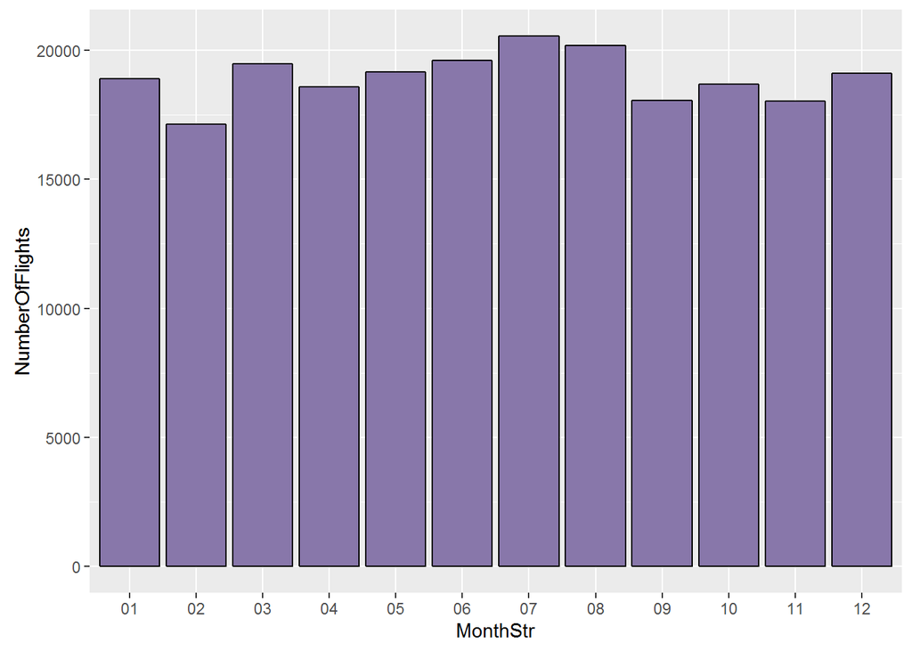

```r
ggplot(monthly_df, aes(x=MonthStr, y=NumberOfFlights)) + geom_bar(fill="#8877aa", color="black", stat="identity")
```

#### Find which months have the highest and lowest flights?

```r
monthly_df_sorted = sqldf("select MonthStr As Month, NumberOfFlights from monthly_df order by NumberOfFlights desc")
head(monthly_df_sorted, 12)
```

```
##    Month NumberOfFlights
## 1     07           20548
## 2     08           20176
## 3     06           19600
## 4     03           19470
## 5     05           19172
## 6     12           19117
## 7     01           18910
## 8     10           18696
## 9     04           18593
## 10    09           18065
## 11    11           18021
## 12    02           17128
```

#### Confirm that all columns are added

```r
head(hflights_df, n=10)
```

```
##      UniqueCarrier Month DayofMonth Year Origin Dest DepTime ArrTime
## 5424            AA     1          1 2011    IAH  DFW    1400    1500
## 5425            AA     1          2 2011    IAH  DFW    1401    1501
## 5426            AA     1          3 2011    IAH  DFW    1352    1502
## 5427            AA     1          4 2011    IAH  DFW    1403    1513
## 5428            AA     1          5 2011    IAH  DFW    1405    1507
## 5429            AA     1          6 2011    IAH  DFW    1359    1503
## 5430            AA     1          7 2011    IAH  DFW    1359    1509
## 5431            AA     1          8 2011    IAH  DFW    1355    1454
## 5432            AA     1          9 2011    IAH  DFW    1443    1554
## 5433            AA     1         10 2011    IAH  DFW    1443    1553
##      DepDelay ArrDelay Cancelled CancellationCode      Date MonthStr
## 5424        0      -10         0                   1/1/2011       01
## 5425        1       -9         0                   1/2/2011       01
## 5426       -8       -8         0                   1/3/2011       01
## 5427        3        3         0                   1/4/2011       01
## 5428        5       -3         0                   1/5/2011       01
## 5429       -1       -7         0                   1/6/2011       01
## 5430       -1       -1         0                   1/7/2011       01
## 5431       -5      -16         0                   1/8/2011       01
## 5432       43       44         0                   1/9/2011       01
## 5433       43       43         0                  1/10/2011       01
```